# Detecting Pneumonia from X-ray Images | Deep Learning

**Description : Prediction of PNEUMONIA based on Chest X-ray Images using Convolutional Neural Network and tensorflow - *Deep Learning approach***

**Python libraries used :**

```
1. Tensorflow
2. Keras
3. Scikit-learn
4. Numpy
5. Matplotlib
6. Seaborn
```

### Import required libraries and load images

```python
import tensorflow as tf
import numpy as np
seed = 232
np.random.seed(seed)
tf.__version__
```

```
'2.0.0'
```

Loading Chest X-Ray images and their labels from local computer. X-Ray image is very huge dataset of 1 GB which is downloaded from Kaggle.

```python
import os

image_path = 'chest_xray_data/chest_xray/'

train_images = ImageDataGenerator(rescale=1./255, vertical_flip=True , zoom_range=0.3)
test_val_images = ImageDataGenerator(rescale=1./255)

# This is fed to the network in the specified batch sizes and image dimensions
x_train = train_images.flow_from_directory(directory = image_path +'train', target_size=(150, 150), batch_size = 32,
                                           class_mode='binary', shuffle=True)

test_data = test_val_images.flow_from_directory(directory=input_path+'test', target_size=(150, 150), batch_size = 32,
                                                class_mode='binary', shuffle=True)
```

```
Found 5216 images belonging to 2 classes.
Found 624 images belonging to 2 classes.
```

```python
import cv2


val_images = []
val_labels = []

test_images = []
test_labels = []

input_path = 'chest_xray_data/chest_xray/'

for i in (['val', 'test']):
    for opt in ['/NORMAL/', '/PNEUMONIA/']:
        for img in (os.listdir(input_path + str(i) + opt)):
            img = plt.imread(input_path + str(i) + opt + img)
            img = cv2.resize(img, (150, 150))
            img = np.dstack([img, img, img])
            img = img.astype('float32') / 255
            if i == 'val':
                if opt =='/NORMAL/':
                    label = 0
                elif opt =='/PNEUMONIA/':
                    label = 1
                val_images.append(img)
                val_labels.append(label)
            elif i == 'test':
                if opt =='/NORMAL/':
                    label = 0
                elif opt =='/PNEUMONIA/':
                    label = 1
                test_images.append(img)
                test_labels.append(label)
```

train_images has all the images required for training. val_images, val_labels, test_images and test_labels contains all images and labels for validation and testing. All these images labels are in the list. Convert this list into numpy arrays

```python
x_val = np.array(val_images)
y_val = np.array(val_labels)

x_test = np.array(test_images)
y_test = np.array(test_labels)


print(x_val.shape, y_val.shape)
print(x_test.shape, y_test.shape)
```

```
(16, 150, 150, 3) (16,)
(624, 150, 150, 3) (624,)
```

## Data Analysis

Inspect the shape and length and type of our train and test dataset.

```python
print(type(x_train))
print(type(y_train))
print(type(x_test))
print(type(y_test))
```

```
<class 'keras.preprocessing.image.DirectoryIterator'>
<class 'numpy.ndarray'>
<class 'numpy.ndarray'>
<class 'numpy.ndarray'>
```

```python
for img in ['train', 'val', 'test']:
    normal_img = len(os.listdir(input_path + img + '/NORMAL'))
    pneumonia_img = len(os.listdir(input_path + img + '/PNEUMONIA'))
    print('Dataset: {} \n Total number of Normal Images: {}, Pneumonia Images: {}\n'.format(img, normal_img, pneumonia_img))
```

```
Dataset: train
 Total number of Normal Images: 1341, Pneumonia Images: 3875

Dataset: val
 Total number of Normal Images: 8, Pneumonia Images: 8

Dataset: test
 Total number of Normal Images: 234, Pneumonia Images: 390
```

### Analizing a sample image and its pixels

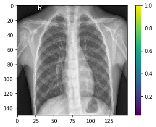

```
0
```

```python
import matplotlib.pyplot as plt
%matplotlib inline

plt.figure()
plt.imshow(x_test[0])
plt.colorbar()
plt.grid(False)
plt.show()

print(y_test[0])
```

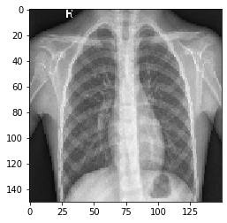

```python
plt.imshow(x_test[0], cmap = plt.cm.gray_r, interpolation = 'nearest')
```

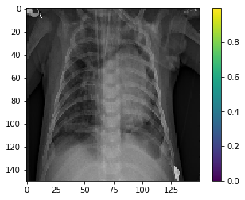

```
1
```

```python
import matplotlib.pyplot as plt

plt.figure()
plt.imshow(x_test[235])
plt.colorbar()
plt.grid(False)
plt.show()

print(y_test[235])
```

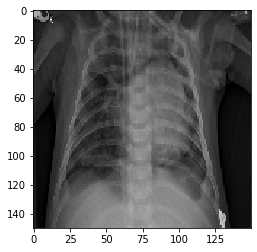

```python
plt.imshow(x_test[235], cmap = plt.cm.gray_r, interpolation = 'nearest')
```

## NORMAL Vs PNEUMONIA

Visulizing X-ray images for 'NORMAL' case from dataset.

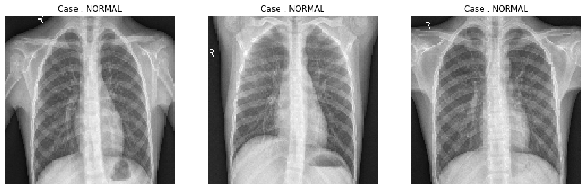

```python
class_name = ['NORMAL', 'PNEUMONIA']
plt.figure(figsize = (15, 10))
for i in range(0, 3):
    plt.subplot(1, 3, i + 1)
    plt.axis('off')
    plt.imshow(x_test[i], cmap = plt.cm.gray_r, interpolation = 'nearest')
    plt.title('Case : ' + class_name[y_test[i]])
```

Visulizing X-ray images for 'PNEUMONIA' case from dataset.

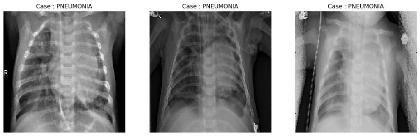

```python
plt.figure(figsize = (15, 10))
for i in range(234, 237):
    plt.subplot(1, 3, i + 1 - 234)
    plt.axis('off')
    plt.imshow(x_test[i], cmap = plt.cm.gray_r, interpolation = 'nearest')
    plt.title('Case : ' + class_name[y_test[i]])
```

We can see the difference between NORMAL and PNEUMONIA cases from images above. Label assigned to each image referes to the index of class which it belongs to (0 - for NORMAL and 1 - for PNEUMONIA).

### Preparing data for training

```python
# Converting into category out of 43 categories
from keras.utils import to_categorical
y_train = to_categorical(y_train, 43)
y_test = to_categorical(y_test, 43)
```

## Convolutional Neural Network

### Building the model

```python
from keras.models import Model, Sequential
from keras.layers import Input, Dense, Flatten, Dropout, BatchNormalization
from keras.layers import Conv2D, SeparableConv2D, MaxPool2D, LeakyReLU, Activation
from keras.optimizers import Adam
from keras.preprocessing.image import ImageDataGenerator
from keras.callbacks import ModelCheckpoint, ReduceLROnPlateau, EarlyStopping

# Creating Different Layers of Convolutional Neural Network - Input, hidden, output.

# Input Layer

input_layer = Input(shape = (150, 150, 3))

# Adding first Convolutional layer and Maxpooking
conv1 = Conv2D(filters=16, kernel_size=(3, 3), activation='relu', padding='same')(input_layer)
conv1 = Conv2D(filters=16, kernel_size=(3, 3), activation='relu', padding='same')(conv1)
conv1 = MaxPool2D(pool_size=(2, 2))(conv1)

# Adding second Convolutional layer and Maxpooking
conv2 = SeparableConv2D(filters=32, kernel_size=(3, 3), activation='relu', padding='same')(conv1)
conv2 = SeparableConv2D(filters=32, kernel_size=(3, 3), activation='relu', padding='same')(conv2)
conv2 = BatchNormalization()(conv2)
conv2 = MaxPool2D(pool_size=(2, 2))(conv2)

# Adding third Convolutional layer and Maxpooking
conv3 = SeparableConv2D(filters=64, kernel_size=(3, 3), activation='relu', padding='same')(conv2)
conv3 = SeparableConv2D(filters=64, kernel_size=(3, 3), activation='relu', padding='same')(conv3)
conv3 = BatchNormalization()(conv3)
conv3 = MaxPool2D(pool_size=(2, 2))(conv3)

# Adding fourth Convolutional layer and Maxpooking
conv4 = SeparableConv2D(filters=128, kernel_size=(3, 3), activation='relu', padding='same')(conv3)
conv4 = SeparableConv2D(filters=128, kernel_size=(3, 3), activation='relu', padding='same')(conv4)
conv4 = BatchNormalization()(conv4)
conv4 = MaxPool2D(pool_size=(2, 2))(conv4)
conv4 = Dropout(rate=0.2)(conv4)

# Adding second Convolutional layer and Maxpooking
conv5 = SeparableConv2D(filters=256, kernel_size=(3, 3), activation='relu', padding='same')(conv4)
conv5 = SeparableConv2D(filters=256, kernel_size=(3, 3), activation='relu', padding='same')(conv5)
conv5 = BatchNormalization()(conv5)
conv5 = MaxPool2D(pool_size=(2, 2))(conv5)
conv5 = Dropout(rate=0.2)(conv5)

# Adding Flatten Layer
flat = Flatten()(conv5)

# Adding first hidden layer with 512 neurons
flat = Dense(units=512, activation='relu')(flat)
flat = Dropout(rate=0.7)(flat)

# Adding second hidden layer with 128 neurons
flat = Dense(units=128, activation='relu')(flat)
flat = Dropout(rate=0.5)(flat)

# Adding third hidden layer with 512 neurons
flat = Dense(units=64, activation='relu')(flat)
flat = Dropout(rate=0.3)(flat)

# Layer with output layer of neural network
output = Dense(units=1, activation='sigmoid')(flat)

# Creating model
model = Model(inputs=inputs, outputs=output)
```

[output not shown]

### Compiling the Model

```python
#Compiling the model with binary crossentropy since we have 2 classes
model.compile(optimizer='adam', loss='binary_crossentropy', metrics=['accuracy'])
```

### Training the Model

```python
# Fitting the training data into CNN Model
hist = model.fit_generator(
           x_train, steps_per_epoch=train_gen.samples // batch_size,
           epochs=10, validation_data=test_gen,
           validation_steps=test_gen.samples // batch_size, callbacks=[checkpoint, lr_reduce])
```

```
Epoch 00003: ReduceLROnPlateau reducing learning rate to 0.0003000000142492354.

Epoch 00005: ReduceLROnPlateau reducing learning rate to 9.000000427477062e-05.

Epoch 00007: ReduceLROnPlateau reducing learning rate to 2.700000040931627e-05.

Epoch 00009: ReduceLROnPlateau reducing learning rate to 8.100000013655517e-06.
```

Model took almost 1 hour and 15 minutes to complete the training. Model is now ready to test or calculate accuracy or predict any random case.

### Calculating CNN Model Accuracy

```python
loss, accuracy = model.evaluate(x_test, y_test)
print('Model Loss is : ', str(loss * 100) + ' %')
print('Model Accuracy is : ', str(accuracy * 100) + ' %')
```

```
Model Loss is :  33.66009277793077 %
Model Accuracy is :  88.14102411270142 %
```

**Accuracy Plot**

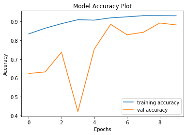

```python
plt.figure(0)
plt.plot(hist.history['accuracy'], label='training accuracy')
plt.plot(hist.history['val_accuracy'], label='val accuracy')
plt.title('Model Accuracy Plot')
plt.xlabel('Epochs')
plt.ylabel('Accuracy')
plt.legend()
plt.show()
```

**Loss Plot**

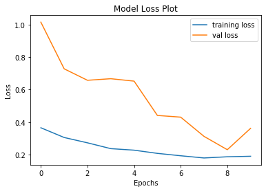

```python
plt.figure(1)
plt.plot(hist.history['loss'], label='training loss')
plt.plot(hist.history['val_loss'], label='val loss')
plt.title('Model Loss Plot')
plt.xlabel('Epochs')
plt.ylabel('Loss')
plt.legend()
plt.show()
```

## Prediction on Test Images

Predicting the values of test images and inspecting if prediction is correct.

```python
y_pred = model.predict(x_test)
```

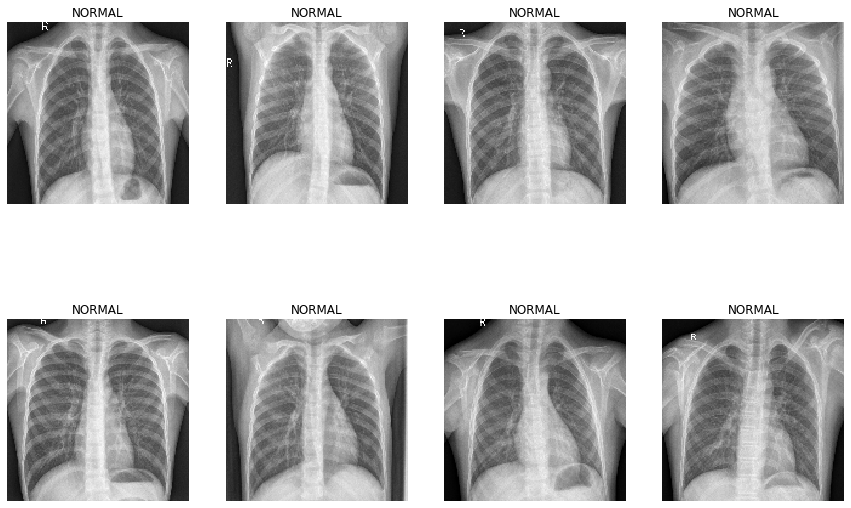

```python
def integer_value(x):
    if x >= 0.5:
        return 1
    else:
        return 0


plt.figure(figsize = (15, 10))
for i in range(0, 8):
    plt.subplot(2, 4, i + 1)
    plt.axis('off')
    plt.imshow(x_test[i], cmap = plt.cm.gray_r, interpolation = 'nearest')
    if y_pred[i] >= 0.5:
        index = 1
    plt.title(class_name[integer_value(y_pred[i])])
```

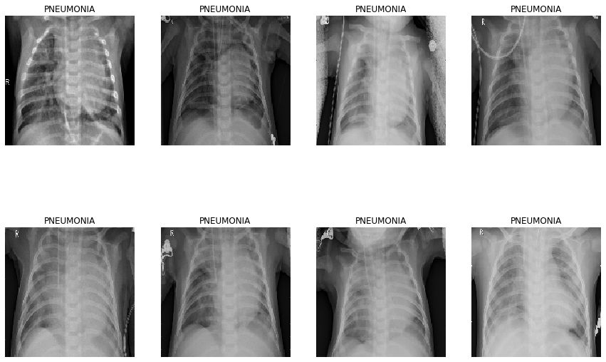

```python
plt.figure(figsize = (15, 10))
for i in range(234, 242):
    plt.subplot(2, 4, i + 1 - 234)
    plt.axis('off')
    plt.imshow(x_test[i], cmap = plt.cm.gray_r, interpolation = 'nearest')
    if y_pred[i] >= 0.5:
        index = 1
    plt.title(class_name[integer_value(y_pred[i])])
```

## Predicting Random Chest X-ray Image

Define a function to display Chest X-ray Image along with its predicted case.

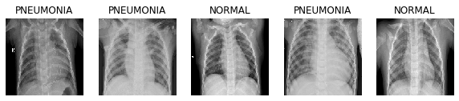

```python
import random

# Function to generate randome index values of specified length
def get_index_list(start, end, num):
    index_list = []
    for i in range(num):
        index_list.append(random.randint(start, end))
    return index_list

# Displaying image and its predicted value
image_index = get_index_list(0, 623, 5)
plt.figure(figsize = (10, 10))
for i in range(len(image_index)):
    plt.subplot(2, 5, i + 1)
    plt.imshow(x_test[image_index[i]], cmap = plt.cm.gray_r, interpolation = 'nearest')
    plt.axis('off')
    plt.title(class_name[integer_value(y_pred[image_index[i]])])
```

Above cell can be run again and again to see different random image result every time.

```python
from sklearn.metrics import confusion_matrix, classification_report

# Function to plot confusion matrix
import matplotlib.pyplot as plt
def get_confusion_matrix(y_test, y_pred):
    import seaborn as sn
    plt.figure(figsize = (6,5))
    sn.heatmap(confusion_matrix(y_test, np.round(y_pred)), cmap="Greens", annot = True)
    plt.xlabel('Predicted Value')
    plt.ylabel('Acual Value')
```

```
Confusion Matrix for Convolutional Neural Network Model is :

 None
```

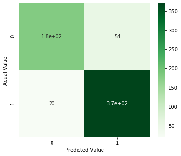

```python
print('\n\n\nConfusion Matrix for Convolutional Neural Network Model is :\n\n', get_confusion_matrix(y_test,y_pred))
```

```python
from sklearn.metrics import accuracy_score, confusion_matrix

acc = accuracy_score(test_labels, np.round(preds))*100
tn, fp, fn, tp = cm.ravel()


print('\nTEST STATS')
precision = tp/(tp+fp)*100
recall = tp/(tp+fn)*100
print('Accuracy: {}%'.format(acc))
print('Precision: {}%'.format(precision))
print('Recall: {}%'.format(recall))
print('F1-score: {}'.format(2*precision*recall/(precision+recall)))

print('\nTRAIN STATS')
print('Train accuracy: {}'.format(np.round((hist.history['accuracy'][-1])*100, 2)))
```

```
TEST STATS
Accuracy: 88.14102564102564%
Precision: 87.26415094339622%
Recall: 94.87179487179486%
F1-score: 90.9090909090909

TRAIN STATS
Train accuracy: 93.04
```